# Introduction to Bulk RNAseq data analysis

Annotation and Visualisation of Differential Expression Results - Solutions

Abbi Edwards

Last modified: 15 Mar 2023

## Exercise 1 - Volcano plot for 33 days

Now it’s your turn! We just made the volcano plot for the 11 days contrast, you will make the one for the 33 days contrast.

If you haven’t already make sure you load in our data and annotation. You can copy and paste the code below.

```r
# First load data and annotations
results.interaction.33 <- readRDS("RObjects/DESeqResults.interaction_d33.rds")
ensemblAnnot <- readRDS("RObjects/Ensembl_annotations.rds")
```

> 1. Shrink the results for the 33 days contrast.

```r
#Shrink our values
ddsShrink.33 <- lfcShrink(ddsObj.interaction,
                       res = results.interaction.33,
                       type = "ashr")
```

```
## using 'ashr' for LFC shrinkage. If used in published research, please cite:
##     Stephens, M. (2016) False discovery rates: a new deal. Biostatistics, 18:2.
##     https://doi.org/10.1093/biostatistics/kxw041
```

```r
shrinkTab.33 <- as.data.frame(ddsShrink.33) %>%
    rownames_to_column("GeneID") %>%
    left_join(ensemblAnnot, "GeneID") %>%
    rename(logFC=log2FoldChange, FDR=padj)
```

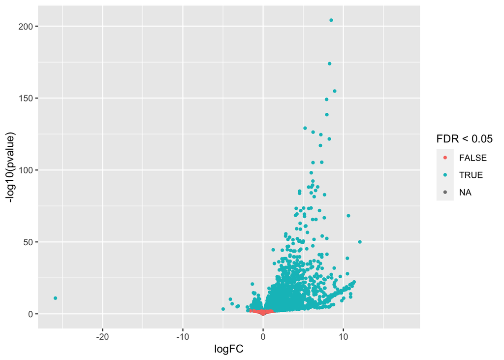

```r
volcanoTab.33 <- shrinkTab.33 %>%
    mutate(`-log10(pvalue)` = -log10(pvalue))

ggplot(volcanoTab.33, aes(x = logFC, y=`-log10(pvalue)`)) +
    geom_point(aes(colour=FDR < 0.05), size=1)
```

## Exercise 2 - MA plot for day 33 with ggplot2

> For this exercise create an MA plot for day 33 like the ones we plotted with `plotMA` from **DESeq2** but this time using ggplot2.

> The x-axis (M) should be the log2 of the mean gene expression across all samples, and the y-axis should be the log2 of the fold change between Infected and Uninfected.

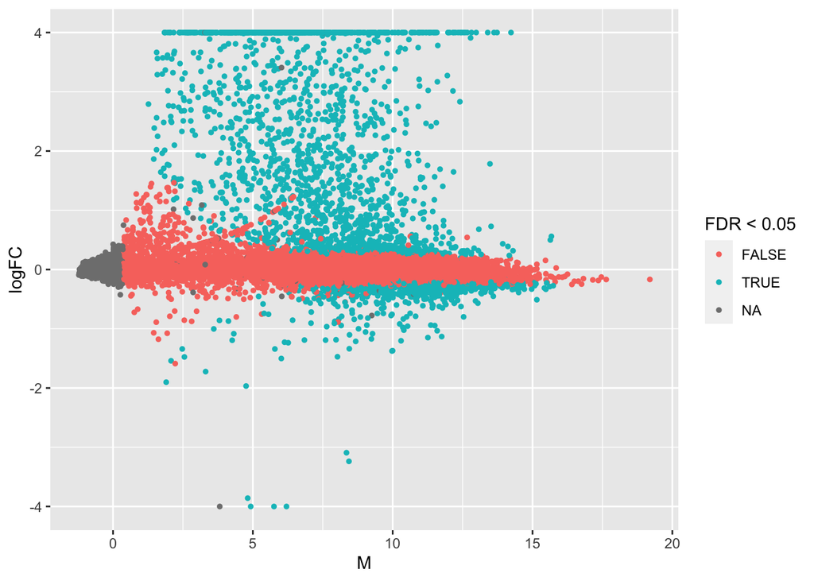

```r
maTab.33 <- shrinkTab.33 %>%
    mutate(`M` = log2(baseMean))

ggplot(maTab.33, aes(x = M, y = logFC)) +
    geom_point(aes(colour=FDR < 0.05), size=1) +
    scale_y_continuous(limit=c(-4,4), oob = scales::squish)
```

## Exercise 3 - Strip Chart

> For this exercise create another strip chart for the gene Jchain.

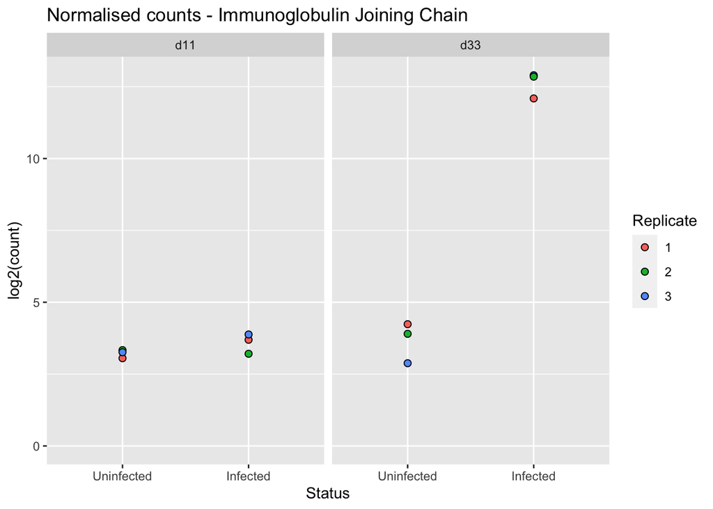

```r
geneID_33 <- filter(shrinkTab.33, Symbol=="Jchain") %>% pull(GeneID)

plotCounts(ddsObj.interaction,
           gene = geneID_33,
           intgroup = c("TimePoint", "Status", "Replicate"),
           returnData = T) %>%
    ggplot(aes(x=Status, y=log2(count))) +
      geom_point(aes(fill=Replicate), shape=21, size=2) +
      facet_wrap(~TimePoint) +
      expand_limits(y=0) +
      labs(title = "Normalised counts - Immunoglobulin Joining Chain")
```